# Time Series Analysis Spring 2023

12. Applications of GARCH Models - estimating Value at Risk

Maciej Świtała

18/05/2023

# Packages and data

```r
library(tidyverse)
library(xts)     # xts objects
library(fBasics) # basicStats()
library(tseries) # jarque.bera.test()
library(car)     # durbinWatsonTest()
library(FinTS)   # ArchTest()
library(fGarch)  # garchFit()
library(rugarch) # e.g. ugarchfit()
```

Introduction to the rugarch package:

- http://cran.r-project.org/web/packages/rugarch/vignettes/Introduction_to_the_rugarch_package.pdf

# Estimating Value-at Risk

This example is based on the paper:

- Engle (2001) GARCH 101: The Use of ARCH/GARCH Models in Applied Econometrics
- http://stat.wharton.upenn.edu/~steele/Courses/434/434Context/GARCH/garch101(ENGLE).pdf

First, let’s download the data from the `csv` file.

```r
NASDAQ <- read.csv("data/ndq_d.csv",
                   header = TRUE,
                   sep = ",",
                   dec = ".",
                   stringsAsFactors = F)
```

Verification of the structure.

```r
str(NASDAQ)
```

```
## 'data.frame':    21310 obs. of  6 variables:
##  $ Date  : chr  "1938-01-03" "1938-01-04" "1938-01-05" "1938-01-06" ...
##  $ Open  : num  5.65 5.75 5.84 5.94 6.1 6.12 6.22 6.36 6.39 6.32 ...
##  $ High  : num  5.75 5.91 5.97 6.12 6.12 6.24 6.39 6.41 6.42 6.33 ...
##  $ Low   : num  5.59 5.75 5.83 5.94 6.02 6.12 6.22 6.3 6.32 6.23 ...
##  $ Close : num  5.63 5.88 5.85 6.11 6.06 6.22 6.35 6.4 6.34 6.25 ...
##  $ Volume: int  NA NA NA NA NA NA NA NA NA NA ...
```

```r
NASDAQ$Date <- as.Date(NASDAQ$Date)
NASDAQ <- NASDAQ[, c("Date", "Close")]
colnames(NASDAQ) <- c("Date", "NASDAQ")
```

Adding log-returns.

```r
NASDAQ$r <- diff.xts(log(NASDAQ$NASDAQ))
```

Removing observations before 1990-03-23.

```r
NASDAQ <- NASDAQ[as.Date("1990-03-23") <= NASDAQ$Date, ]
```

Adding current number of observation.

```r
NASDAQ$obs <- 1:length(NASDAQ$NASDAQ)
```

Verification of the structure.

```r
str(NASDAQ)
```

```
## 'data.frame':    7594 obs. of  4 variables:
##  $ Date  : Date, format: "1990-03-23" "1990-03-26" ...
##  $ NASDAQ: num  437 439 440 437 435 ...
##  $ r     : num  0.00642 0.00342 0.00159 -0.00639 -0.00298 ...
##  $ obs   : int  1 2 3 4 5 6 7 8 9 10 ...
```

```r
head(NASDAQ, n = 10)
```

```
##             Date NASDAQ             r obs
## 13717 1990-03-23 437.30  0.0064235137   1
## 13718 1990-03-26 438.80  0.0034242700   2
## 13719 1990-03-27 439.50  0.0015939887   3
## 13720 1990-03-28 436.70 -0.0063912566   4
## 13721 1990-03-29 435.40 -0.0029813117   5
## 13722 1990-03-30 435.50  0.0002296475   6
## 13723 1990-04-02 433.20 -0.0052952812   7
## 13724 1990-04-03 437.70  0.0103342291   8
## 13725 1990-04-04 435.40 -0.0052685954   9
## 13726 1990-04-05 433.42 -0.0045579140  10
```

```r
tail(NASDAQ, n = 10)
```

```
##             Date   NASDAQ            r  obs
## 21301 2020-04-28 8607.731 -0.014123403 7585
## 21302 2020-04-29 8914.710  0.035041968 7586
## 21303 2020-04-30 8889.551 -0.002826179 7587
## 21304 2020-05-01 8604.948 -0.032539155 7588
## 21305 2020-05-04 8710.715  0.012216490 7589
## 21306 2020-05-05 8809.121  0.011233785 7590
## 21307 2020-05-06 8854.388  0.005125493 7591
## 21308 2020-05-07 8979.661  0.014048976 7592
## 21309 2020-05-08 9121.320  0.015652399 7593
## 21310 2020-05-11 9192.344  0.007756433 7594
```

Pot of quotations and returns.

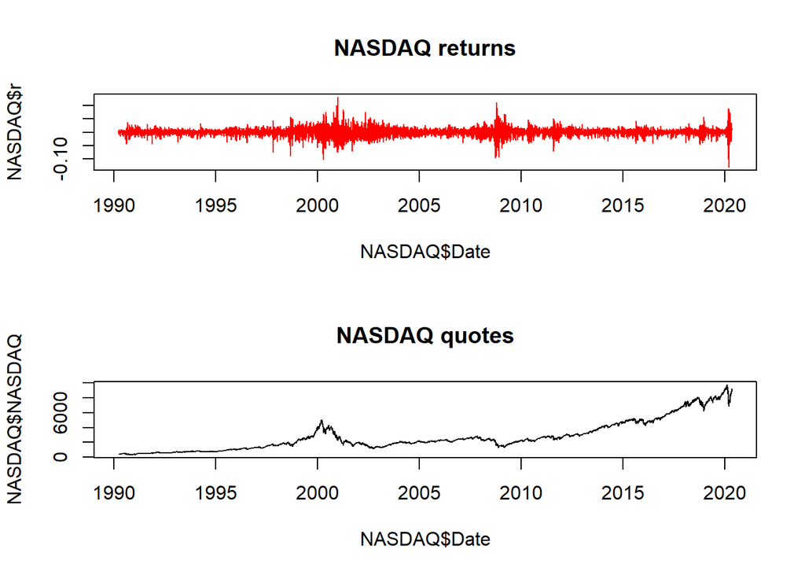

```r
par(mfrow = c(2, 1))
plot(NASDAQ$Date, NASDAQ$r,
     type = "l", col = "red", lwd = 1,
     main = "NASDAQ returns")
plot(NASDAQ$Date, NASDAQ$NASDAQ,
     type = "l", col = "black", lwd = 1,
     main = "NASDAQ quotes")
```

```r
par(mfrow = c(1, 1))
```

Plot of ACF for returns

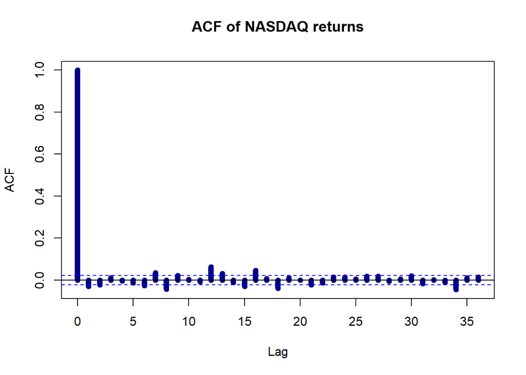

```r
acf(NASDAQ$r, lag.max = 36, na.action = na.pass,
    col = "darkblue", lwd = 7,
    main = "ACF of NASDAQ returns")
```

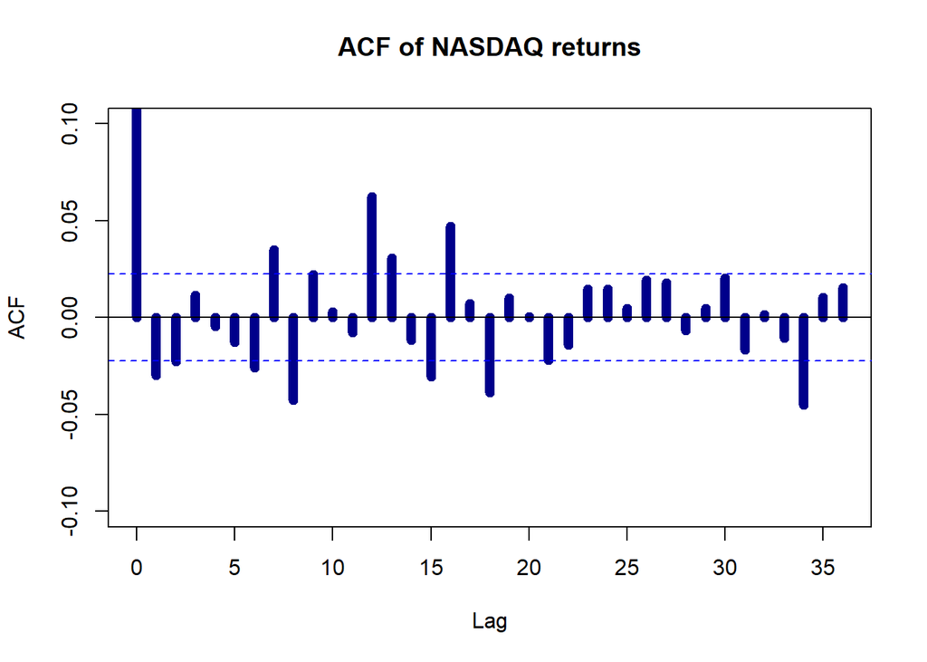

```r
acf(NASDAQ$r, lag.max = 36, na.action = na.pass,
     ylim = c(-0.1, 0.1), # we rescale the vertical axis
     col = "darkblue", lwd = 7,
     main = "ACF of NASDAQ returns")
```

Based on the ACF analysis for NASDAQ returns, we can say that there is - to some extent - an autoregressive relationship among returns.

Plot of ACF for **squared returns**.

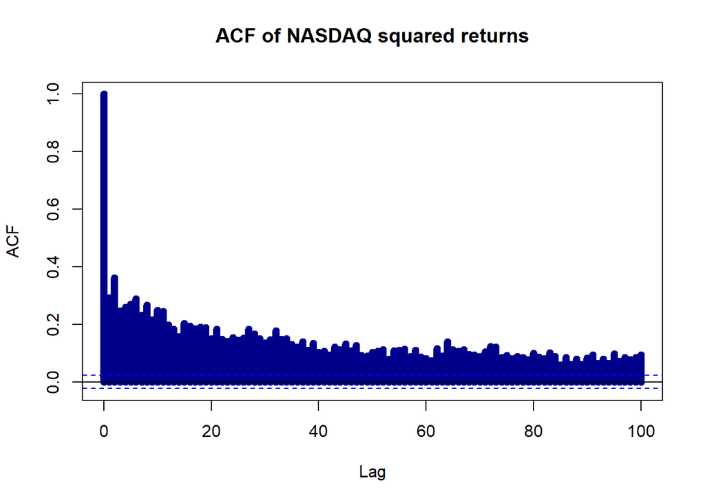

```r
acf(NASDAQ$r^2, lag.max = 100, na.action = na.pass,
    col = "darkblue", lwd = 7,
    main = "ACF of NASDAQ squared returns")
```

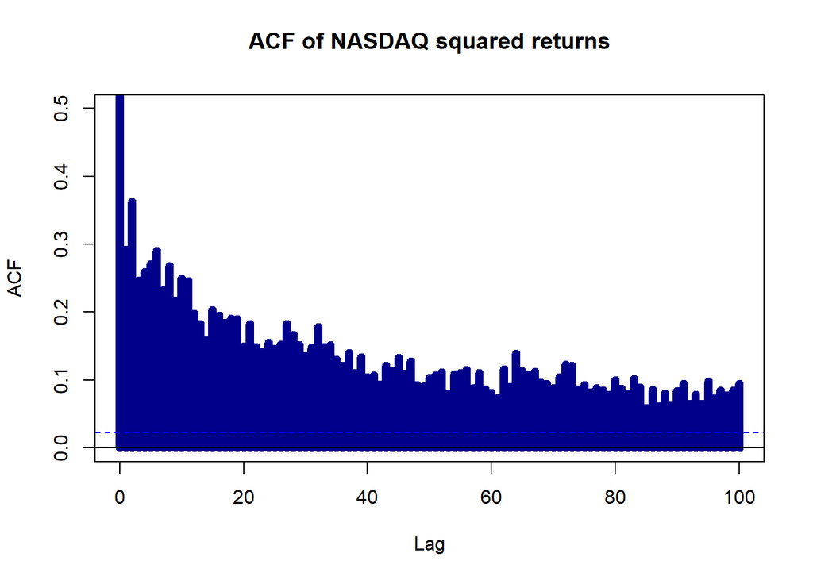

```r
acf(NASDAQ$r^2, lag.max = 100, na.action = na.pass,
    ylim = c(0, 0.5), # we rescale the vertical axis
    col = "darkblue", lwd = 7,
    main = "ACF of NASDAQ squared returns")
```

Plot of ACF for squares of NASDAQ returns shows a clear autoregressive relationship among them, which allows to conclude that ARCH effects are present in the log-returns. We can verify a formal hypothesis about this.

Testing for ARCH effects.

```r
ArchTest(NASDAQ$r, lags = 5)
```

```
##
##  ARCH LM-test; Null hypothesis: no ARCH effects
##
## data:  NASDAQ$r
## Chi-squared = 1519.3, df = 5, p-value < 2.2e-16
```

```r
durbinWatsonTest(lm(NASDAQ$r^2 ~ 1),
                 max.lag = 5) # first 5 lags
```

```
##  lag Autocorrelation D-W Statistic p-value
##    1       0.2921410      1.415701       0
##    2       0.3623309      1.275309       0
##    3       0.2466181      1.506720       0
##    4       0.2592885      1.481359       0
##    5       0.2704767      1.458967       0
##  Alternative hypothesis: rho[lag] != 0
```

Do returns come from normal distribution?

```r
basicStats(NASDAQ$r)
```

```
##             X..NASDAQ.r
## nobs        7594.000000
## NAs            0.000000
## Minimum       -0.131491
## Maximum        0.132546
## 1. Quartile   -0.005624
## 3. Quartile    0.007329
## Mean           0.000402
## Median         0.001097
## Sum            3.051930
## SE Mean        0.000168
## LCL Mean       0.000072
## UCL Mean       0.000732
## Variance       0.000215
## Stdev          0.014655
## Skewness      -0.198750
## Kurtosis       7.284552
```

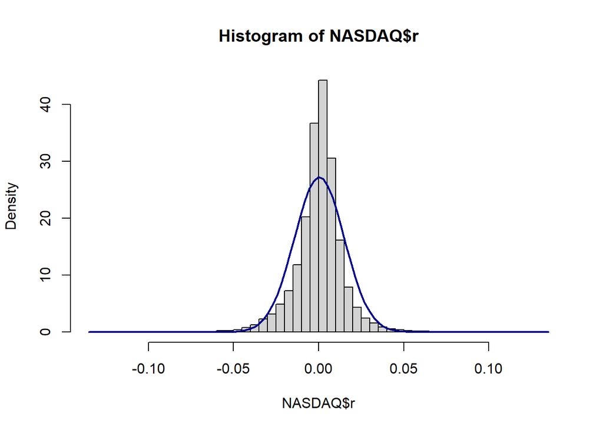

```r
hist(NASDAQ$r, prob = T, breaks = 40)
curve(dnorm(x, mean = mean(NASDAQ$r, na.rm = T),
            sd  = sd(NASDAQ$r, na.rm = T)),
            col = "darkblue", lwd = 2, add = TRUE)
```

```r
jarque.bera.test(na.omit(NASDAQ$r))
```

```
##
##  Jarque Bera Test
##
## data:  na.omit(NASDAQ$r)
## X-squared = 16853, df = 2, p-value < 2.2e-16
```

```r
durbinWatsonTest(lm(NASDAQ$r ~ 1),
                 max.lag = 5) # first 5 lags
```

```
##  lag Autocorrelation D-W Statistic p-value
##    1    -0.029649852      2.059244   0.004
##    2    -0.022819756      2.045436   0.046
##    3     0.011503690      1.976674   0.336
##    4    -0.004349403      2.008338   0.678
##    5    -0.012738403      2.025037   0.250
##  Alternative hypothesis: rho[lag] != 0
```

Removing observations before `1990-03-23` and after `2000-03-23`.

```r
NASDAQ2 <- NASDAQ[NASDAQ$Date <= as.Date("2000-03-23"), ]
NASDAQ2 <- NASDAQ2[as.Date("1990-03-23") <= NASDAQ2$Date, ]
```

Plots fo quotations and returns.

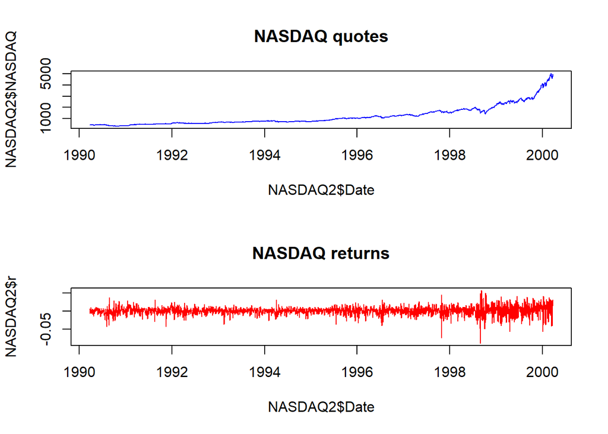

```r
par(mfrow = c(2, 1))
plot(NASDAQ2$Date, NASDAQ2$NASDAQ,
     type = 'l', lwd = 1, col = "blue",
     main = 'NASDAQ quotes')
plot(NASDAQ2$Date, NASDAQ2$r,
     type = 'l', lwd = 1, col = "red" ,
     main = "NASDAQ returns")
```

```r
par(mfrow = c(1, 1))
```

Standardization of returns.

```r
NASDAQ2$rstd <- (NASDAQ2$r - mean(NASDAQ2$r, na.rm = T)) /
    sd(NASDAQ2$r ,na.rm = T)
tail(NASDAQ2)
```

```
##             Date  NASDAQ           r  obs      rstd
## 16239 2000-03-16 4717.39  0.02898479 2523  2.401869
## 16240 2000-03-17 4798.13  0.01697058 2524  1.372129
## 16241 2000-03-20 4610.00 -0.03999840 2525 -3.510694
## 16242 2000-03-21 4711.68  0.02181668 2526  1.787489
## 16243 2000-03-22 4864.75  0.03197079 2527  2.657800
## 16244 2000-03-23 4940.61  0.01547348 2528  1.243812
```

Descriptive statistics of standardized returns .

```r
basicStats(NASDAQ2$rstd)
```

```
##             X..NASDAQ2.rstd
## nobs            2528.000000
## NAs                0.000000
## Minimum           -7.756582
## Maximum            4.929819
## 1. Quartile       -0.490490
## 3. Quartile        0.542921
## Mean               0.000000
## Median             0.042715
## Sum                0.000000
## SE Mean            0.019889
## LCL Mean          -0.039000
## UCL Mean           0.039000
## Variance           1.000000
## Stdev              1.000000
## Skewness          -0.527628
## Kurtosis           4.317505
```

1% empirical quantile

```r
q01 <- quantile(NASDAQ2$rstd, 0.01, na.rm = T)
q01
```

```
##        1%
## -2.939957
```

For comparison: 1% quantile of standard normal distribution

```r
qnorm(0.01, 0, 1)
```

```
## [1] -2.326348
```

What are the conclusions?

Estimating the GARCH(1,1) model.

```r
spec <-
  ugarchspec(variance.model = list(model = "sGARCH", garchOrder = c(1, 1)),
             mean.model = list(armaOrder = c(0, 0), include.mean = T),
             distribution.model = "norm")
nasdaq2.garch11 <- ugarchfit(spec = spec, data = na.omit(NASDAQ2$r))
```

Plots

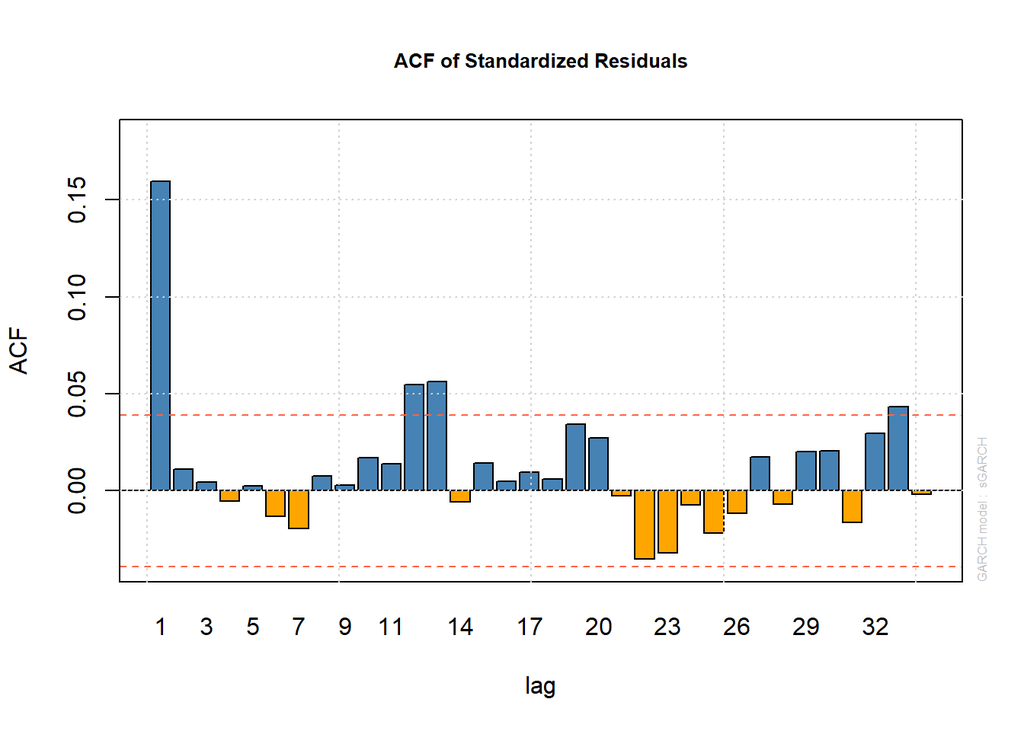

```r
plot(nasdaq2.garch11, which = 10)
```

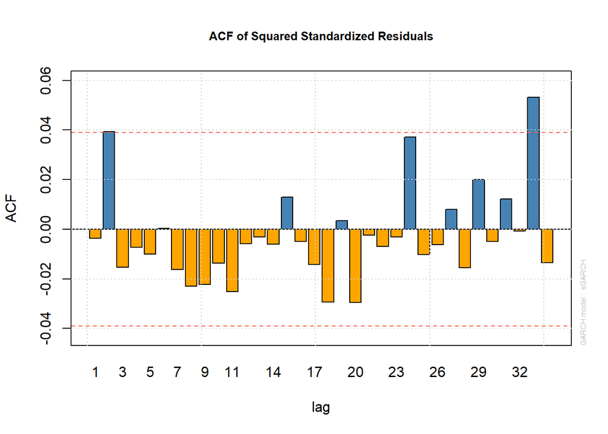

```r
plot(nasdaq2.garch11, which = 11)
```

# VaR in the IN-SAMPLE period

Structure of the new object.

```r
str(nasdaq2.garch11)
```

```
## Formal class 'uGARCHfit' [package "rugarch"] with 2 slots
##   ..@ fit  :List of 27
##   .. ..$ hessian        : num [1:4, 1:4] 31542840 -527909261 -19011 -1760 -527909261 ...
##   .. ..$ cvar           : num [1:4, 1:4] 0.0000000327698 0.0000000000533 0.0000003459035 -0.0000006001519 0.0000000000533 ...
##   .. ..$ var            : num [1:2528] 0.0001361 0.0001229 0.0001086 0.0000958 0.0000918 ...
##   .. ..$ sigma          : num [1:2528] 0.01166 0.01109 0.01042 0.00979 0.00958 ...
##   .. ..$ condH          : num 9.29
##   .. ..$ z              : num [1:2528] 0.4686 0.2226 0.0611 -0.7508 -0.4111 ...
##   .. ..$ LLH            : num 8031
##   .. ..$ log.likelihoods: num [1:2528] -3.42 -3.56 -3.64 -3.43 -3.64 ...
##   .. ..$ residuals      : num [1:2528] 0.005466 0.002467 0.000637 -0.007348 -0.003938 ...
##   .. ..$ coef           : Named num [1:4] 0.00095714 0.00000349 0.12845006 0.84920005
##   .. .. ..- attr(*, "names")= chr [1:4] "mu" "omega" "alpha1" "beta1"
##   .. ..$ robust.cvar    : num [1:4, 1:4] 0.000000041102 0.000000000535 0.000002794021 -0.000005431815 0.000000000535 ...
##   .. ..$ A              : num [1:4, 1:4] 12477.389 -208824.866 -7.52 -0.696 -208824.866 ...
##   .. ..$ B              : num [1:4, 1:4] 15780 -4832292 -200 -322 -4832292 ...
##   .. ..$ scores         : num [1:2528, 1:4] -40.2 -25.5 -14.3 72.8 44.9 ...
##   .. .. ..- attr(*, "dimnames")=List of 2
##   .. .. .. ..$ : NULL
##   .. .. .. ..$ : chr [1:4] "mu" "omega" "alpha1" "beta1"
##   .. ..$ se.coef        : num [1:4] 0.00018102 0.00000169 0.01659369 0.02002688
##   .. ..$ tval           : Named num [1:4] 5.29 2.07 7.74 42.4
##   .. .. ..- attr(*, "names")= chr [1:4] "mu" "omega" "alpha1" "beta1"
##   .. ..$ matcoef        : num [1:4, 1:4] 0.00095714 0.00000349 0.12845006 0.84920005 0.00018102 ...
##   .. .. ..- attr(*, "dimnames")=List of 2
##   .. .. .. ..$ : chr [1:4] "mu" "omega" "alpha1" "beta1"
##   .. .. .. ..$ : chr [1:4] " Estimate" " Std. Error" " t value" "Pr(>|t|)"
##   .. ..$ robust.se.coef : num [1:4] 0.00020274 0.00000761 0.03579433 0.06748329
##   .. ..$ robust.tval    : Named num [1:4] 4.721 0.459 3.589 12.584
##   .. .. ..- attr(*, "names")= chr [1:4] "mu" "omega" "alpha1" "beta1"
##   .. ..$ robust.matcoef : num [1:4, 1:4] 0.00095714 0.00000349 0.12845006 0.84920005 0.00020274 ...
##   .. .. ..- attr(*, "dimnames")=List of 2
##   .. .. .. ..$ : chr [1:4] "mu" "omega" "alpha1" "beta1"
##   .. .. .. ..$ : chr [1:4] " Estimate" " Std. Error" " t value" "Pr(>|t|)"
##   .. ..$ fitted.values  : num [1:2528] 0.000957 0.000957 0.000957 0.000957 0.000957 ...
##   .. ..$ convergence    : num 0
##   .. ..$ kappa          : num 1
##   .. ..$ persistence    : num 0.978
##   .. ..$ timer          : 'difftime' num 0.155389070510864
##   .. .. ..- attr(*, "units")= chr "secs"
```

[output cut: 35 more lines]

```
##   .. .. .. ..$ : chr [1:19] "mu" "ar" "ma" "arfima" ...
##   .. .. .. ..$ : chr [1:6] "Level" "Fixed" "Include" "Estimate" ...
##   .. ..$ start.pars: NULL
##   .. ..$ fixed.pars: NULL
##   .. ..$ maxOrder  : num 1
##   .. ..$ pos.matrix: num [1:21, 1:3] 1 0 0 0 0 0 2 3 4 0 ...
##   .. .. ..- attr(*, "dimnames")=List of 2
##   .. .. .. ..$ : chr [1:21] "mu" "ar" "ma" "arfima" ...
##   .. .. .. ..$ : chr [1:3] "start" "stop" "include"
##   .. ..$ fmodel    : NULL
##   .. ..$ pidx      : num [1:19, 1:2] 1 2 3 4 5 6 7 8 9 10 ...
##   .. .. ..- attr(*, "dimnames")=List of 2
##   .. .. .. ..$ : chr [1:19] "mu" "ar" "ma" "arfima" ...
##   .. .. .. ..$ : chr [1:2] "begin" "end"
##   .. ..$ n.start   : num 0
```

```r
head(nasdaq2.garch11@fit$sigma)
```

```
## [1] 0.011664915 0.011085145 0.010422248 0.009787048 0.009579625 0.009133137
```

Calculating value-at-risk (VaR).

```r
NASDAQ2$VaR <- q01 * nasdaq2.garch11@fit$sigma
tail(NASDAQ2)
```

```
##             Date  NASDAQ           r  obs      rstd         VaR
## 16239 2000-03-16 4717.39  0.02898479 2523  2.401869 -0.07022776
## 16240 2000-03-17 4798.13  0.01697058 2524  1.372129 -0.07134793
## 16241 2000-03-20 4610.00 -0.03999840 2525 -3.510694 -0.06810103
## 16242 2000-03-21 4711.68  0.02181668 2526  1.787489 -0.07635981
## 16243 2000-03-22 4864.75  0.03197079 2527  2.657800 -0.07392427
## 16244 2000-03-23 4940.61  0.01547348 2528  1.243812 -0.07575462
```

Plot of returns vs value-at-risk.

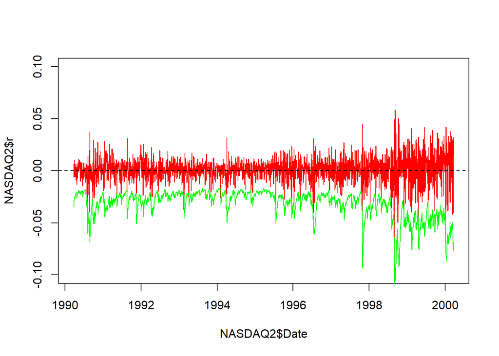

```r
plot(NASDAQ2$Date, NASDAQ2$r,
     col = "red", lwd = 1, type = 'l',
     ylim = c(-0.1, 0.1))
abline(h = 0, lty = 2)
lines(NASDAQ2$Date, NASDAQ2$VaR, type = 'l', col = "green")
```

In how many days losses were higher than the assumed value-at-risk?

```r
sum(NASDAQ2$r < NASDAQ2$VaR) / length(NASDAQ2$VaR)
```

```
## [1] 0.007515823
```

Let’s limit the sample to the last year only and compare the results.

```r
NASDAQ3 <- NASDAQ[NASDAQ$Date <= as.Date("2000-03-23"), ]
NASDAQ3 <- NASDAQ3[as.Date("1999-03-23") <= NASDAQ3$Date, ]
NASDAQ3$rstd <-
  (NASDAQ3$r - mean(NASDAQ3$r, na.rm = T)) / sd(NASDAQ3$r, na.rm = T)
q01  <- quantile(NASDAQ3$rstd, 0.01, na.rm = T)
spec <-
  ugarchspec(variance.model = list(model = "sGARCH", garchOrder = c(1, 1)),
             mean.model = list(armaOrder = c(0, 0), include.mean = T),
             distribution.model = "norm")
nasdaq3.garch11 <- ugarchfit(spec = spec, data = na.omit(NASDAQ3$r))
NASDAQ3$VaR     <- q01 * nasdaq3.garch11@fit$sigma
tail(NASDAQ3)
```

```
##             Date  NASDAQ           r  obs       rstd         VaR
## 16239 2000-03-16 4717.39  0.02898479 2523  1.3964889 -0.05125617
## 16240 2000-03-17 4798.13  0.01697058 2524  0.7548126 -0.05024871
## 16241 2000-03-20 4610.00 -0.03999840 2525 -2.2878864 -0.04756517
## 16242 2000-03-21 4711.68  0.02181668 2526  1.0136415 -0.05235297
## 16243 2000-03-22 4864.75  0.03197079 2527  1.5559705 -0.04974706
## 16244 2000-03-23 4940.61  0.01547348 2528  0.6748529 -0.04985523
```

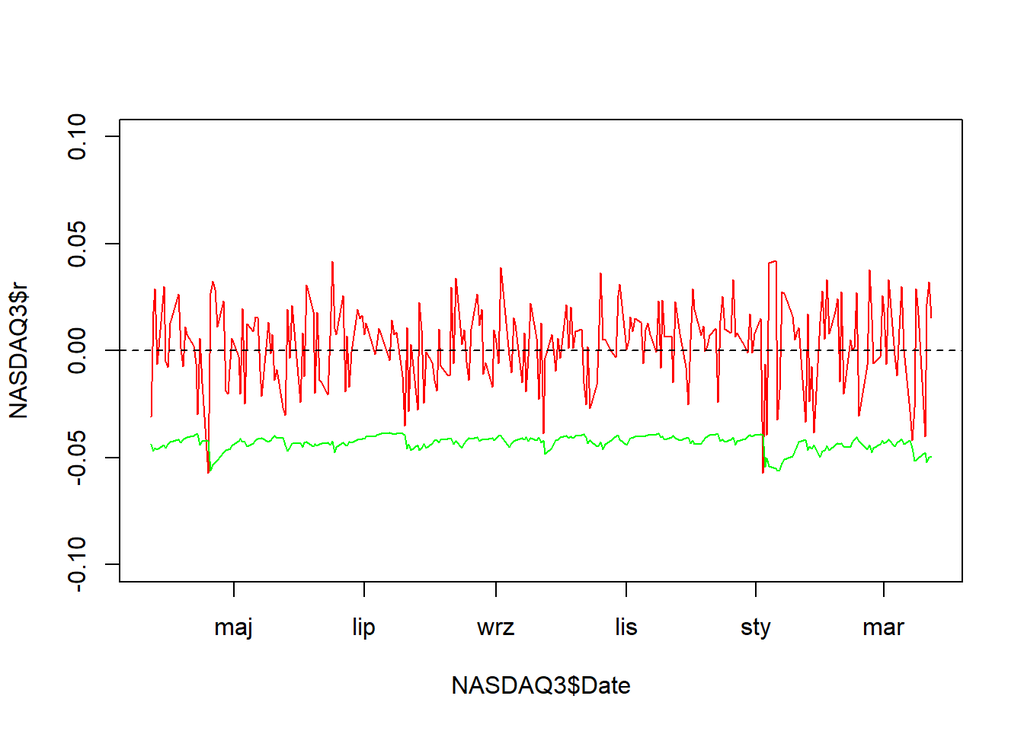

```r
plot(NASDAQ3$Date, NASDAQ3$r, col = "red",
     lwd = 1, type = 'l', ylim = c(-0.1, 0.1))
abline(h = 0, lty = 2)
lines(NASDAQ3$Date, NASDAQ3$VaR, type = 'l', col = "green")
```

```r
sum(NASDAQ3$r < NASDAQ3$VaR) / length(NASDAQ3$VaR)
```

```
## [1] 0.007843137
```

What are the conclusions?

# VaR in the OUT-OF-SAMPLE period

Plot of conditional standard deviation and its on-day ahead prediction.

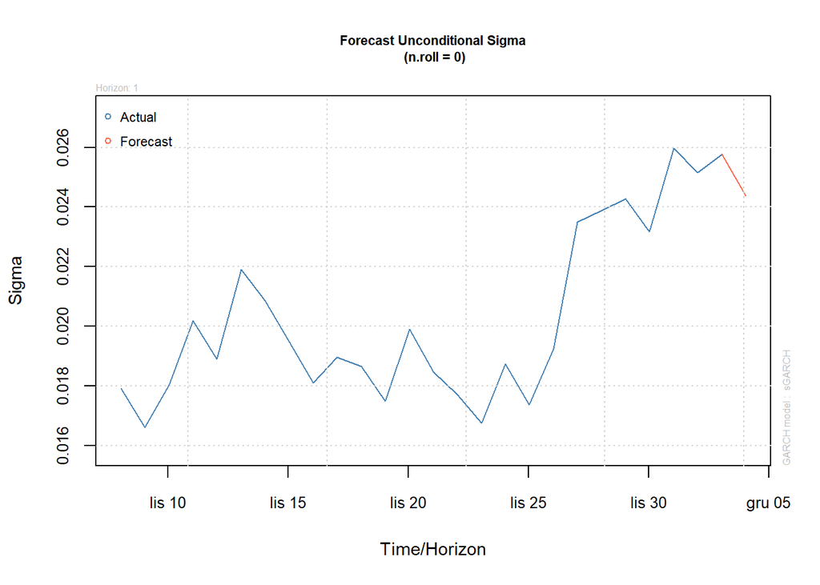

```r
plot(ugarchforecast(nasdaq2.garch11, n.ahead = 1), which = 3)
```

Plot of conditional standard deviation forecasts in the long run.

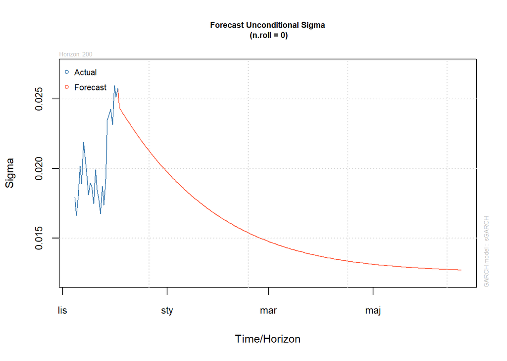

```r
plot(ugarchforecast(nasdaq2.garch11, n.ahead = 200), which = 3)
```

We can combine them with the in-sample estimation of conditional standard deviation

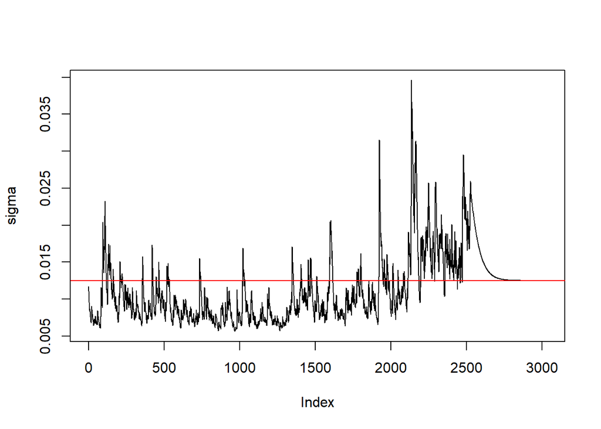

```r
sigma.forecast.longrun <- ugarchforecast(nasdaq2.garch11, n.ahead = 500)
unconditional_sigma <-
  sqrt(
    nasdaq2.garch11@model$pars["omega", 1] /
      (1 -
         nasdaq2.garch11@model$pars["alpha1", 1] -
         nasdaq2.garch11@model$pars["beta1", 1]))
plot(
  c(as.numeric(nasdaq2.garch11@fit$sigma),
    as.numeric(sigma.forecast.longrun@forecast$sigmaFor)),
  type = "l",
  ylab = "sigma")
abline(h = unconditional_sigma, col = "red")
```

Yet a better idea is to annualize all of these values.

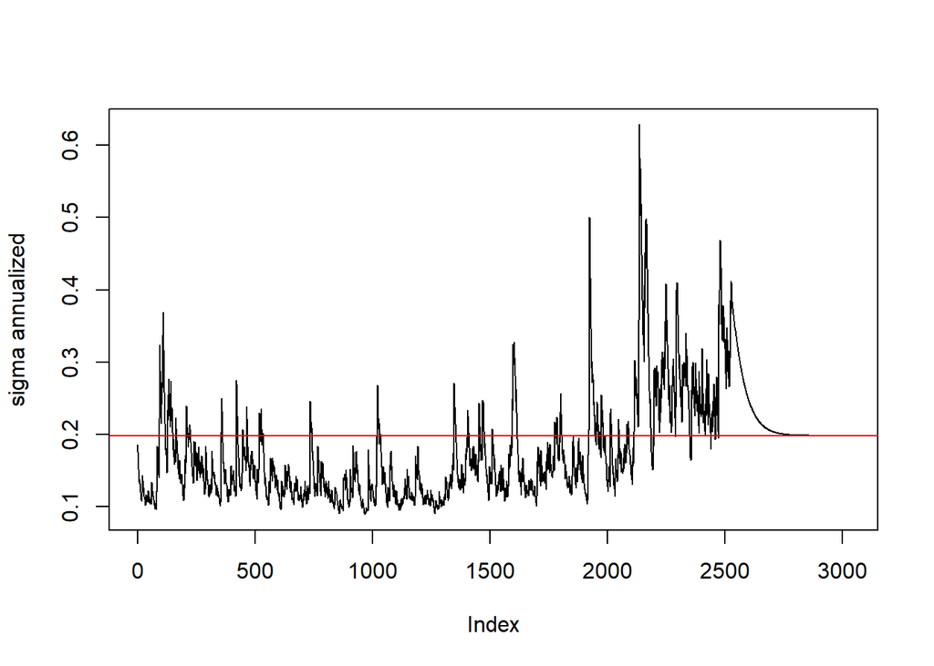

```r
plot(
  c(as.numeric(nasdaq2.garch11@fit$sigma * sqrt(252)),
    as.numeric(sigma.forecast.longrun@forecast$sigmaFor * sqrt(252))),
  type = "l",
  ylab = "sigma annualized")
abline(h = unconditional_sigma * sqrt(252), col = "red")
```

We can see that maximum value of estimated conditional standard deviation (sigma) was 62.9% annualized, while its long term uncoditional level was 19.8% annualized.

Let’s go back to sigma in daily scale and generate one-day ahead prediction of conditional variance.

```r
sigma.forecast <- ugarchforecast(nasdaq2.garch11, n.ahead = 1)
```

Structure of the new object.

```r
str(sigma.forecast)
```

```
## Formal class 'uGARCHforecast' [package "rugarch"] with 2 slots
##   ..@ forecast:List of 6
##   .. ..$ n.ahead  : num 1
##   .. ..$ N        : num 2528
##   .. ..$ n.start  : num 0
##   .. ..$ n.roll   : num 0
##   .. ..$ sigmaFor : num [1, 1] 0.0244
##   .. .. ..- attr(*, "dimnames")=List of 2
##   .. .. .. ..$ : chr "T+1"
##   .. .. .. ..$ : chr "1976-12-03 01:00:00"
##   .. ..$ seriesFor: num [1, 1] 0.000957
##   .. .. ..- attr(*, "dimnames")=List of 2
##   .. .. .. ..$ : chr "T+1"
##   .. .. .. ..$ : chr "1976-12-03 01:00:00"
##   ..@ model   :List of 11
##   .. ..$ modelinc  : Named num [1:22] 1 0 0 0 0 0 1 1 1 0 ...
##   .. .. ..- attr(*, "names")= chr [1:22] "mu" "ar" "ma" "arfima" ...
##   .. ..$ modeldesc :List of 3
##   .. .. ..$ distribution: chr "norm"
##   .. .. ..$ distno      : int 1
##   .. .. ..$ vmodel      : chr "sGARCH"
##   .. ..$ modeldata :List of 6
##   .. .. ..$ T        : int 2528
##   .. .. ..$ data     : num [1:2528] 0.00642 0.00342 0.00159 -0.00639 -0.00298 ...
##   .. .. ..$ index    : POSIXct[1:2528], format: "1970-01-02 01:00:00" ...
##   .. .. ..$ period   : 'difftime' num 1
##   .. .. .. ..- attr(*, "units")= chr "days"
##   .. .. ..$ sigma    : num [1:2528] 0.01166 0.01109 0.01042 0.00979 0.00958 ...
##   .. .. ..$ residuals: num [1:2528] 0.005466 0.002467 0.000637 -0.007348 -0.003938 ...
##   .. ..$ pars      : num [1:19, 1:6] 0.000957 0 0 0 0 ...
##   .. .. ..- attr(*, "dimnames")=List of 2
##   .. .. .. ..$ : chr [1:19] "mu" "ar" "ma" "arfima" ...
##   .. .. .. ..$ : chr [1:6] "Level" "Fixed" "Include" "Estimate" ...
##   .. ..$ start.pars: NULL
##   .. ..$ fixed.pars: NULL
##   .. ..$ maxOrder  : num 1
##   .. ..$ pos.matrix: num [1:21, 1:3] 1 0 0 0 0 0 2 3 4 0 ...
##   .. .. ..- attr(*, "dimnames")=List of 2
##   .. .. .. ..$ : chr [1:21] "mu" "ar" "ma" "arfima" ...
##   .. .. .. ..$ : chr [1:3] "start" "stop" "include"
##   .. ..$ fmodel    : NULL
##   .. ..$ pidx      : num [1:19, 1:2] 1 2 3 4 5 6 7 8 9 10 ...
##   .. .. ..- attr(*, "dimnames")=List of 2
##   .. .. .. ..$ : chr [1:19] "mu" "ar" "ma" "arfima" ...
##   .. .. .. ..$ : chr [1:2] "begin" "end"
##   .. ..$ n.start   : num 0
```

```r
str(sigma.forecast@forecast)
```

```
## List of 6
##  $ n.ahead  : num 1
##  $ N        : num 2528
##  $ n.start  : num 0
##  $ n.roll   : num 0
##  $ sigmaFor : num [1, 1] 0.0244
##   ..- attr(*, "dimnames")=List of 2
##   .. ..$ : chr "T+1"
##   .. ..$ : chr "1976-12-03 01:00:00"
##  $ seriesFor: num [1, 1] 0.000957
##   ..- attr(*, "dimnames")=List of 2
##   .. ..$ : chr "T+1"
##   .. ..$ : chr "1976-12-03 01:00:00"
```

```r
sigma.forecast@forecast$sigmaFor
```

```
##     1976-12-03 01:00:00
## T+1          0.02438004
```

Since it is a list cointaining one element (data.frame object), we have to extract it:

```r
sigma.forecast2 <- sigma.forecast@forecast$sigmaFor[1, 1]
```

We calculate 1-day head forecast of VaR:

```r
q01 * sigma.forecast2
```

```
##          1%
## -0.05682165
```

Now, the loop below calculates predictions of VaR for the whole **OUT-OF-SAMPLE** period

```r
start   <- NASDAQ$obs[NASDAQ$Date == as.Date("2000-03-24")]
finish  <- NASDAQ$obs[NASDAQ$Date == as.Date("2001-03-23")]
NASDAQ4 <- NASDAQ[start:finish, ]
VaR <- rep(NA, times = finish - start + 1)

mu     <- rep(NA, times = finish - start + 1)
omega  <- rep(NA, times = finish - start + 1)
alpha1 <- rep(NA, times = finish - start + 1)
beta1  <- rep(NA, times = finish - start + 1)
```

```r
time1 <- Sys.time()
for (k in start:finish) {
    tmp.data <- NASDAQ[NASDAQ$obs <= (k - 1), ]
    tmp.data <- tmp.data[as.Date("1990-03-23") <= tmp.data$Date, ]
    tmp.data$rstd <-
      (tmp.data$r - mean(tmp.data$r, na.rm = T)) / sd(tmp.data$r, na.rm = T)
    q01  <- quantile(tmp.data$rstd, 0.01, na.rm = T)
    spec <-
      ugarchspec(variance.model = list(model = "sGARCH", garchOrder = c(1, 1)),
                 mean.model     = list(armaOrder = c(0, 0), include.mean = T),
                 distribution.model = "norm")
    tmp.garch11           <- ugarchfit(spec = spec, data = na.omit(tmp.data$r))
    sigma.forecast        <- ugarchforecast(tmp.garch11, n.ahead = 1)
    sigma.forecast2       <- sigma.forecast@forecast$sigmaFor[1, 1]
    VaR[k - start + 1]    <- q01 * sigma.forecast2
    mu[k - start + 1]     <- tmp.garch11@fit$coef[1]
    omega[k - start + 1]  <- tmp.garch11@fit$coef[2]
    alpha1[k - start + 1] <- tmp.garch11@fit$coef[3]
    beta1[k - start + 1]  <- tmp.garch11@fit$coef[4]
  }
time2 <- Sys.time()
time2 - time1
```

```
## Time difference of 1.017701 mins
```

Adding VaR values to the data.frame objects.

```r
NASDAQ4$VaR <- VaR
```

Verification of the first and last observations .

```r
head(NASDAQ4)
```

```
##             Date  NASDAQ             r  obs         VaR
## 16245 2000-03-24 4963.03  0.0045276360 2529 -0.07167628
## 16246 2000-03-27 4958.56 -0.0009010653 2530 -0.06634875
## 16247 2000-03-28 4833.89 -0.0254638495 2531 -0.06143959
## 16248 2000-03-29 4644.67 -0.0399312009 2532 -0.06326648
## 16249 2000-03-30 4457.89 -0.0410447657 2533 -0.07318650
## 16250 2000-03-31 4572.83  0.0254567093 2534 -0.08145454
```

```r
tail(NASDAQ4)
```

```
##             Date  NASDAQ           r  obs         VaR
## 16491 2001-03-16 1890.91 -0.02599569 2775 -0.10393268
## 16492 2001-03-19 1951.18  0.03137612 2776 -0.10058398
## 16493 2001-03-20 1857.44 -0.04923512 2777 -0.09900296
## 16494 2001-03-21 1830.23 -0.01475755 2778 -0.10791257
## 16495 2001-03-22 1897.70  0.03620098 2779 -0.10128196
## 16496 2001-03-23 1928.68  0.01619320 2780 -0.10165460
```

Plot of returns vs. VaR in the **OUT-OF-SAMPLE** period

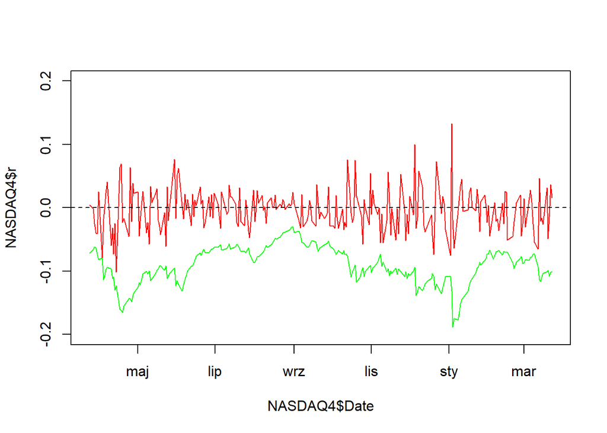

```r
plot(NASDAQ4$Date, NASDAQ4$r, col = "red", lwd = 1, type = 'l',
     ylim = c(-0.20, 0.20))
abline(h = 0, lty = 2)
lines(NASDAQ4$Date, NASDAQ4$VaR, type = 'l', col = "green")
```

In how many days losses were higher than the assumed VaR?

```r
sum(NASDAQ4$r < NASDAQ4$VaR) / length(NASDAQ4$VaR)
```

```
## [1] 0
```

# Exercise 13

## Exercise 13.1

Build a portfolio consisting of three financial assets. For simplicity, assume that at the beginning of each trading day weights are the same (for example: 50%, 30%, 20%). Use GARCH(1,1) in rolling approach to estimate VaR in the out-of-sample period.

## Exercise 13.2

In the example above: instead of GARCH(1,1) use EGARCH(1,1). How will that affect the out-of-sample VaR estimates?

## Exercise 13.3

In the example above: to calculate 1% empirical quantile, perform standardization of residuals using the their conditional standard deviation instead of unconditional # standard deviation. How will that affect the out-of-sample VaR estimates?

## Exercise 13.4

In the example above: instead of 1% empirical quantile, use 1% quantile of standard normal distribution, which is qnorm(0.01) = -2.326348. How will that affect the out-of-sample VaR estimates?

## Exercise 13.5 (*)

In the example above: instead of the GARCH(1,1) model, to estimate 1% out-of-sample VaR use 1% quantile of standard normal distribution and as the volatility prediction apply unconditional standard deviation of returns based on the rolling sample of last 21 (or 63 or 126) historical trading days. How will that affect the out-of-sample VaR estimates?